# Data That Saves Lives (and Dollars): An Introduction to Healthcare Analytics

ASC Workshop

Tyson Barrett, PhD

2026-10-26

# Let’s talk jobs!

## The Field Is Growing

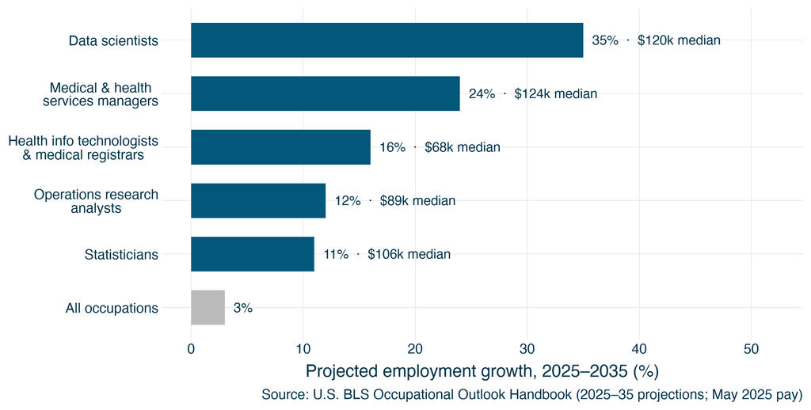

**Insurance carriers** are among the top employers of data scientists (10%).

**Note**

These are projections and are most certainly impacted by AI and other market changes.

## Where the Jobs Are

**Payers (insurers)**

Claims, cost of care, risk adjustment, HEDIS / Star ratings

**Providers (health systems)**

EHR reporting, quality, operations, readmissions

**Pharma & life sciences**

Real-world evidence, outcomes research

**Health tech & data vendors**

Products built on claims / SDOH data

**Consulting**

Value-based care, program evaluation

**Government & public health**

Medicaid, state health departments, CDC

**Note**

**In Utah:** Intermountain Health / Select Health, University of Utah Health, Optum, HealthEquity, Regence BCBS, Utah DHHS, County Dept of Health

## What Postings Ask For

*From seven real postings (accessed Oct 16, 2026).*

**Provider Data Analyst**  
*Intermountain Health (2 postings)*

- **SQL**, database design; **Python and/or R**
- **Epic Clarity** / Cerner data
- Dashboards for clinical leaders
- Present findings to clinical & business teams
- BS + 2 yrs · $39–68/hr

**Payer / Claims Analyst**  
*Optum · USM (HEDIS)*

- Cost, utilization & reimbursement trends in **claims**
- **HEDIS** measures, care gaps, audits
- **SQL**, SAS, Tableau / Power BI, Excel
- Medicare, Commercial, Medicaid payment models
- BS + 3 yrs · $92k–164k (Optum)

**Health Data Scientist**  
*Cohere Health · Dandelion Health · GDIT*

- **Causal inference** with claims, EHR & SDOH data
- ML / AI on Medicare & Medicaid **claims**
- **ICD, CPT, NDC** codes
- **Python, R, SQL**, Spark
- MS+ (or BS + 5 yrs) · $98k–155k

**Common thread:** SQL + a language + healthcare data fluency + **explaining results to non-analysts.**

Postings: Intermountain Health, *Data Analyst, Statistical Senior* and *Data Analyst-Technical-Staff*; Optum, *Senior Healthcare Analytics Consultant*; USM, *HEDIS Data Analyst (SQL)*; Cohere Health, *Senior Data Scientist*; Dandelion Health, *Research Consultant, Data Scientist*; GDIT, *Sr. Healthcare Data Scientist (Medicare/Medicaid)*. Links in Sources.

# What Did I Do in Healthcare Analytics?

## GLP-1s vs Bariatric Surgery

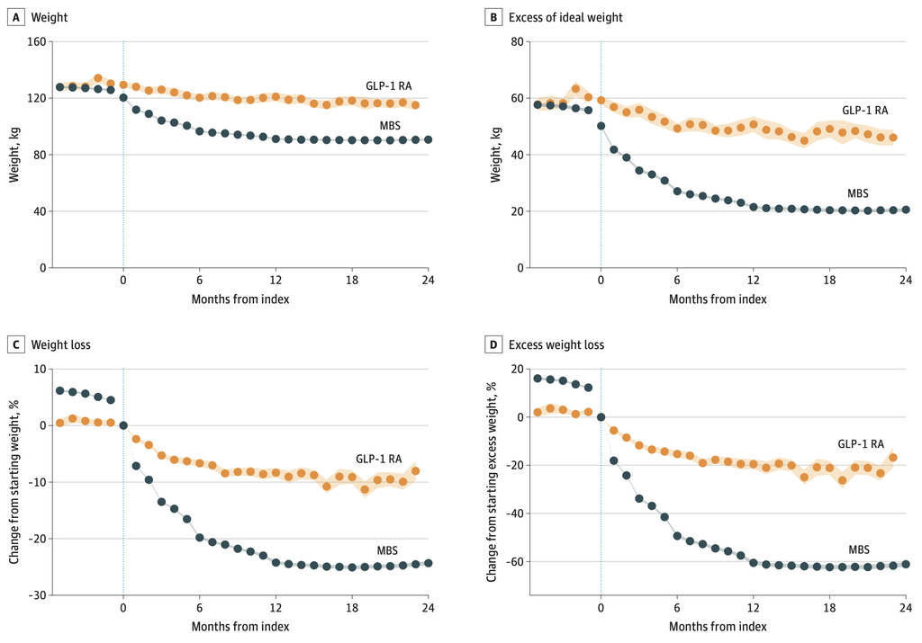

**Data:** Highmark claims + AHN EHR (weights)

**Design:** 30,458 patients with class II/III obesity; propensity-score weighting; mixed-effects models for monthly cost

Barrett et al. (2025). *JAMA Surgery*, 160(11), 1232–1239.

## Depression: Finding It and Costing It

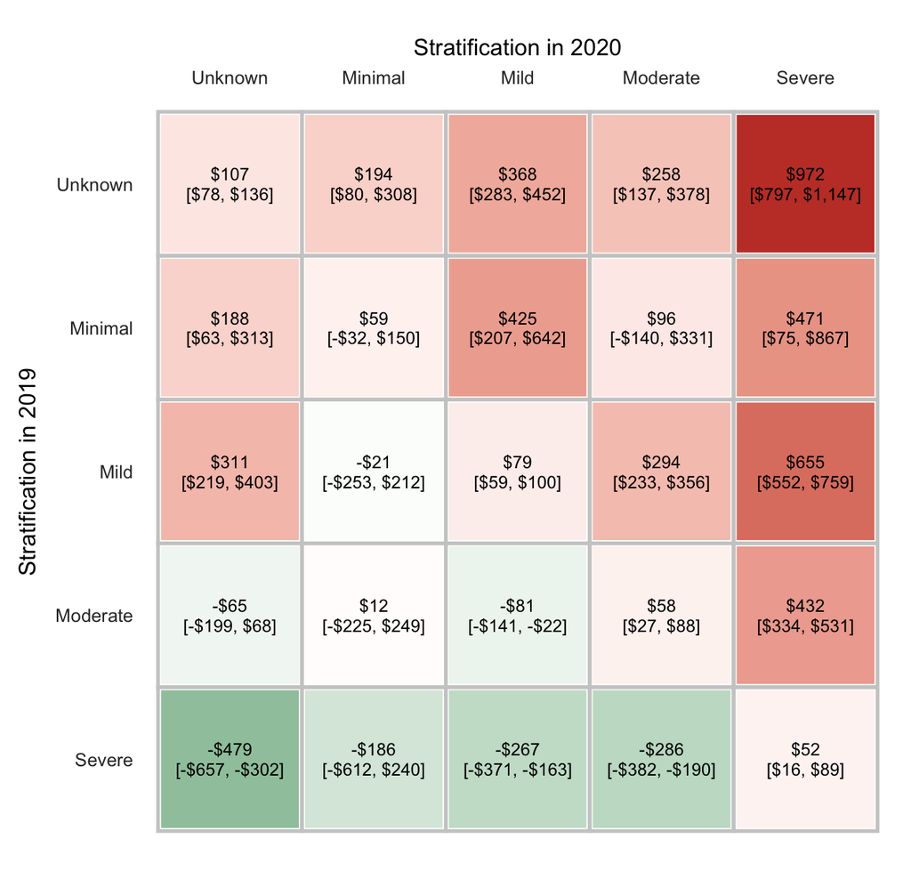

**Identify & stratify** with claims + EHR (Dx, Rx, PHQ-9, utilization)

- Found **720,882** members with depression
- **258,206 more** than diagnosis codes alone

**Cost of severity change** (PMPM, 2019 → 2020)

- Severity ↑ : **+$608** PMPM on average
- Severity ↓ : **−$41** PMPM

Popkov, Barrett, et al. (2026). *J Behav Health Serv Res*; Popkov, Barrett, et al. (2025). *J Affect Disord*, 368, 41–47.

You’ll try a mini version of this with diabetes in the hands-on section.

## Palliative Care: Payor-Provider Partnership

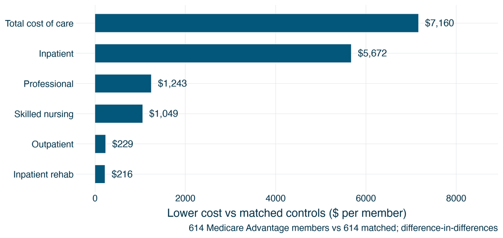

## More from the Same Toolkit

| Question | Data | Method | Finding |
| --- | --- | --- | --- |
| Is adolescent depression screening equitable? | Claims + **SVI** | Multilevel logistic | Higher SVI → lower screening odds; pediatricians OR = 9.6 |
| What does insomnia cost? | Claims, ~3M members | Propensity matching, GLMs | 9% have insomnia, **21%** of total spend |
| Does measurement-based care reduce ED use? | Claims + registry | Negative binomial, survival | **34% lower** ED visit rate (IRR = 0.66) |

Galper et al. (2025) *AJPH*; Karlin et al. (2024) *Sleep Adv*; Breitzig et al. (2026) *Adm Policy Ment Health*.

Every one started as a **business question** from a clinical or finance partner.

# The Healthcare Data Landscape

## The Data

Highmark is a **payor-provider** system: an insurer (Highmark) *and* a health network (Allegheny Health Network). Similar to Intermountain Health.

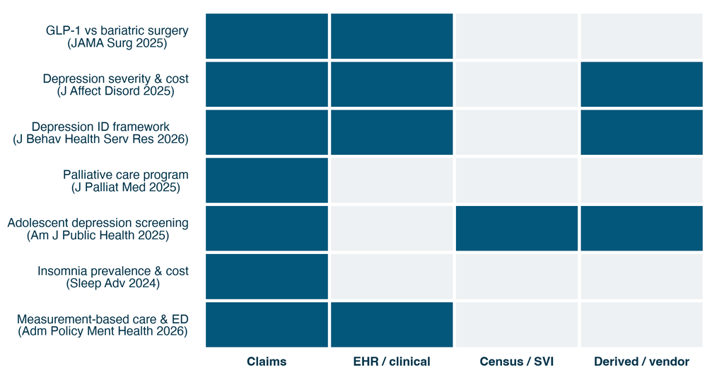

## Four Sources, Four Lenses

|  | **Claims** | **EHR** | **Public / Census** | **Vendor** |
| --- | --- | --- | --- | --- |
| **What** | Bills sent to an insurer | Clinical record of care | ACS, CDC SVI, PLACES | Purchased SDOH, consumer, benchmark data |
| **Grain** | One row per service line | One row per encounter / lab / vital | One row per ZIP, tract, county | One row per person (if matched) |
| **Owner** | Payers (Highmark, Medicaid) | Providers (Epic, Cerner) | Government | Data companies |
| **Strength** | Complete *billed* picture across all providers, with **cost** | Clinical detail: labs, vitals, PHQ-9 | Free, broad context | Fills social gaps |
| **What in the H*ck?!** | No results, codes ≠ truth, reversals | Only *in-network* care, messy entry | Area ≠ person (ecological) | Match rates, black-box methods |

## How They Link

```
flowchart LR
  M["<b>members</b><br>member_id · zip · plan"]
  C["<b>claims</b><br>member_id · dx · $"]
  X["<b>mrn_crosswalk</b><br>mrn ↔ member_id"]
  E["<b>ehr_encounters</b><br>mrn · bmi · a1c · phq9"]
  Z["<b>census_zip</b><br>zip · svi · income"]
  V["<b>vendor_sdoh</b><br>member_id · food insecurity"]
  C -- member_id --> M
  E -- mrn --> X -- member_id --> M
  Z -- zip --> M
  V -- "member_id<br>(83% match)" --> M
  classDef hub fill:#01364C,color:#fff,stroke:#01364C
  classDef t fill:#F5F5F5,stroke:#01364C,color:#01364C
  class M hub
  class C,X,E,Z,V t
```

**The hardest part of healthcare analytics is usually the joins and data prep, not the model.**

# Hands-On: “Juniper Health Plan Data”

## Meet the Data

*Juniper Health Plan* is **fictitious** — 3,000 Utah members in 2025.

```python
claims  = pd.read_csv("data/claims.csv", parse_dates=["service_date"])
members = pd.read_csv("data/members.csv", parse_dates=["enroll_start", "enroll_end"])
ehr     = pd.read_csv("data/ehr_encounters.csv", parse_dates=["encounter_date"])
xwalk   = pd.read_csv("data/mrn_crosswalk.csv")
census  = pd.read_csv("data/census_zip.csv", dtype={"zip": str})
vendor  = pd.read_csv("data/vendor_sdoh.csv")
members["zip"] = members["zip"].astype(str)
members["age"] = 2025 - members["birth_year"]
```

```
claims     27948
members     3000
ehr         4783
xwalk       1857
census        12
vendor      2494
Name: rows, dtype: int64
```

# Claims

## What a Claim Looks Like

```python
(
    claims
    .sample(6, random_state=3)
    [["member_id", "service_date", "place_of_service", "dx1", "procedure_or_drug", "paid_amt"]]
    .reset_index(drop=True)
)
```

|  | member_id | service_date | place_of_service | dx1 | procedure_or_drug | paid_amt |
| --- | --- | --- | --- | --- | --- | --- |
| 0 | M100754 | 2025-12-24 | 11 Office | E66.01 | 99213 | 151.11 |
| 1 | M100997 | 2025-02-26 | Pharmacy | NaN | GLP-1 RA | 660.51 |
| 2 | M101877 | 2025-04-23 | 11 Office | E11.9 | 99214 | 110.34 |
| 3 | M101270 | 2025-04-26 | 02 Telehealth | R51.9 | 99213 | 126.94 |
| 4 | M101523 | 2025-07-31 | 11 Office | M54.50 | 99213 | 137.19 |
| 5 | M100818 | 2025-12-08 | Pharmacy | NaN | inhaled corticosteroid | 32.93 |

- `dx1` = ICD-10 diagnosis · `procedure_or_drug` = CPT code or drug class
- `place_of_service` tells you *where*: office, ED (23), inpatient (21), telehealth (02)

## What in the H*ck?! Reversals

Claims get reversed and resubmitted. Sum dollars **by claim** before anything else.

```python
claims["claim_status"].value_counts()
```

```
claim_status
paid        27535
reversed      413
Name: count, dtype: int64
```

```python
net = (
    claims
    .groupby(["claim_id", "member_id", "service_date", "claim_type",
              "place_of_service", "dx1", "procedure_or_drug"], dropna=False)
    [["allowed_amt", "paid_amt"]]
    .sum()
    .reset_index()
)
net = net[net["paid_amt"] > 0]          # fully reversed claims drop out
len(claims), len(net)
```

```
(27948, 27122)
```

## PMPM: The Payer’s Favorite Metric

**P**er **M**ember **P**er **M**onth = total paid ÷ member-months

```python
paid = net.groupby("member_id")["paid_amt"].sum()
mem = members.assign(
    paid=members["member_id"].map(paid).fillna(0))

pmpm = (
    mem
    .groupby("plan_type")
    [["paid", "member_months"]]
    .sum()
)
pmpm["pmpm"] = pmpm["paid"]/pmpm["member_months"]
pmpm["pmpm"].round(0)
```

```
plan_type
Commercial            151.0
Medicaid              183.0
Medicare Advantage    313.0
Name: pmpm, dtype: float64
```

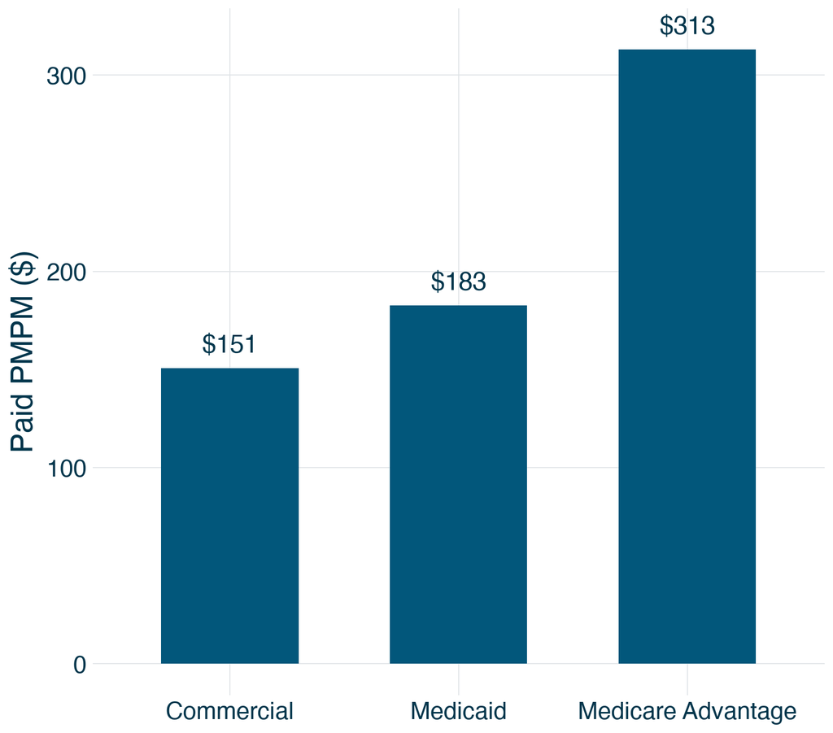

Why divide by member-months? Not everyone is enrolled all year.

## Cost Is Concentrated

The top **5%** of members account for **43%** of spend; the top 20% for **76%**.

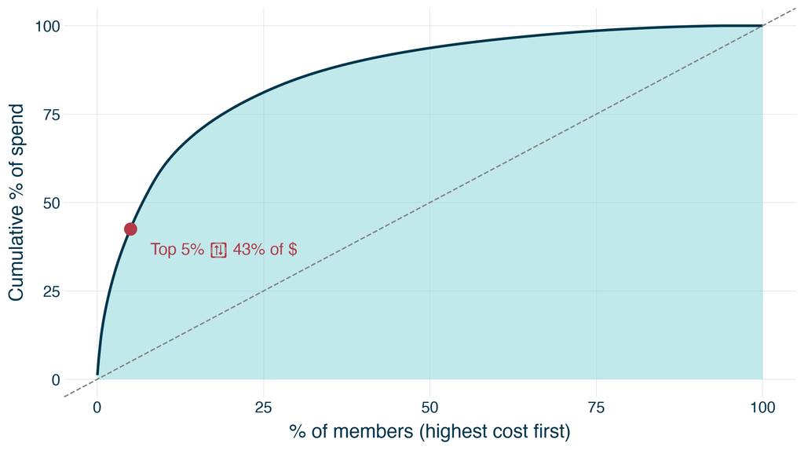

This is why care management programs target “high utilizers.”

## Where Does the Money Go?

```python
by_pos = (
    net
    .groupby("place_of_service")
    ["paid_amt"]
    .agg(["sum", "size"])
)
by_pos["share_of_$"] = by_pos["sum"] / by_pos["sum"].sum()
by_pos["share_of_claims"] = by_pos["size"] / by_pos["size"].sum()
```

| place_of_service | share_of_claims | share_of_$ |
| --- | --- | --- |
| 02 Telehealth | 0.07 | 0.04 |
| 11 Office | 0.32 | 0.17 |
| 21 Inpatient Hospital | 0.00 | 0.34 |
| 23 Emergency Room | 0.03 | 0.22 |
| Pharmacy | 0.57 | 0.23 |

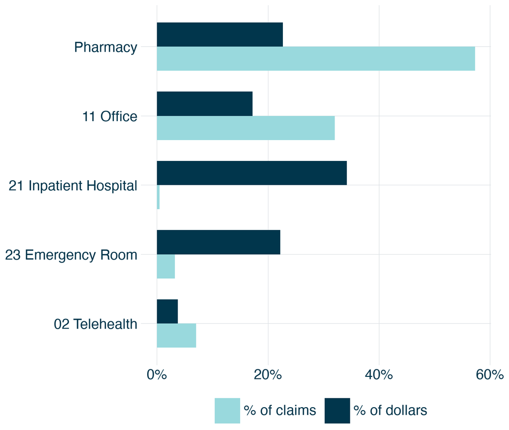

Inpatient: few claims, big dollars. Pharmacy: most claims, dollars driven by a few drugs.

## Your Turn: Claims

**5 minutes**

1. Which **diagnosis codes** (`dx1`) show up most in ED visits (`place_of_service == "23 Emergency Room"`)?
2. What share of pharmacy dollars goes to **GLP-1 RA**? How many members fill one?

```python
ed = net[net["place_of_service"].str.startswith("23")]
print(ed["dx1"].value_counts().head(3))
```

```
dx1
R07.9    156
J06.9    153
R55      145
Name: count, dtype: int64
```

```python
rx = net[net["claim_type"] == "pharmacy"]
print(rx.groupby("procedure_or_drug")["paid_amt"].sum().div(rx["paid_amt"].sum()).round(2).sort_values().tail(3))
print("Members filling a GLP-1:", rx.loc[rx["procedure_or_drug"] == "GLP-1 RA", "member_id"].nunique())
```

```
procedure_or_drug
ACE inhibitor             0.04
inhaled corticosteroid    0.06
GLP-1 RA                  0.86
Name: paid_amt, dtype: float64
Members filling a GLP-1: 191
```

# Electronic Health Records

## Linking EHR to Claims

EHRs use a **medical record number (MRN)**, not a member ID. We need a crosswalk.

```python
ehr_m = ehr.merge(xwalk, on="mrn", how="left")
cov = members["member_id"].isin(ehr_m["member_id"]).mean()
```

```
62% of members have any EHR data
```

The rest got care **outside** this health system: the EHR only sees in-network care.

## What in the H*ck?! Data Entry Errors

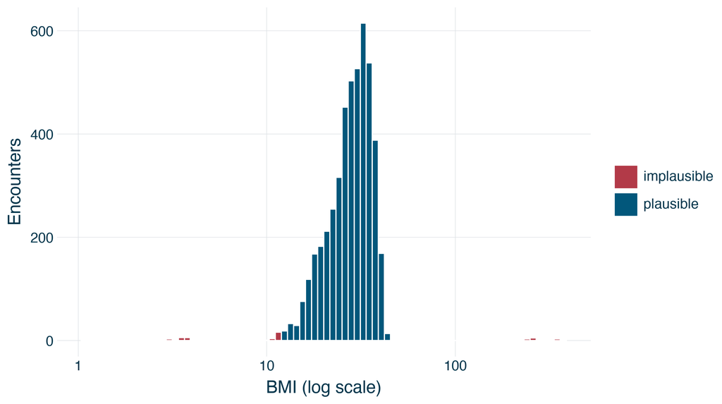

```python
ehr_m.loc[~ehr_m["bmi"].between(12, 70), "bmi"] = np.nan   # set impossible values to missing
```

## Who Has Diabetes? Depends Who You Ask

```python
dx  = set(net.loc[net["dx1"] == "E11.9", "member_id"])
rx  = set(net.loc[net["procedure_or_drug"] == "metformin", "member_id"])
lab = set(ehr_m.loc[ehr_m["a1c"] >= 6.5, "member_id"])

def found_by(m):
    hits = [n for n, ids in [("Dx", dx), ("Rx", rx), ("Lab", lab)]
            if m in ids]
    return " + ".join(hits) or "none"

linked = ehr_m["member_id"].dropna().unique()
combo = (
    pd.Series([found_by(m) for m in linked])
    .value_counts()
    .drop("none")
)
```

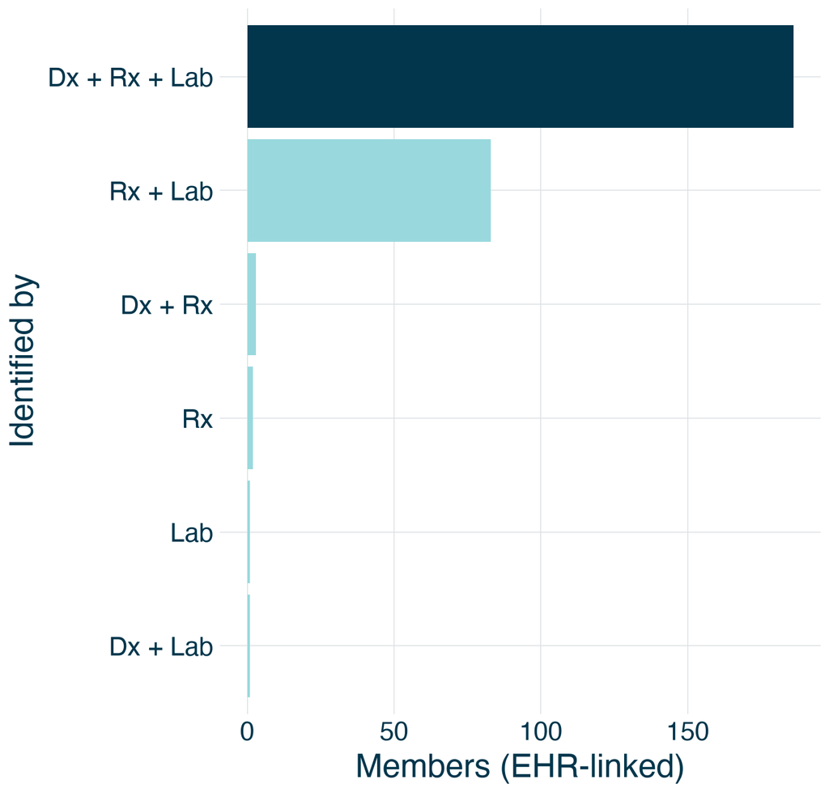

Any single source **misses people**. Combining claims with EHR labs gives a fuller picture (the same idea as the Highmark depression framework).

## Your Turn: EHR

**5 minutes**

Use each linked member’s **highest PHQ-9** to assign depression severity (0–4 none/minimal, 5–9 mild, 10–14 moderate, 15–19 mod-severe, 20+ severe). How many with a PHQ-9 ≥ 10 have **no** depression diagnosis (`F32*`/`F33*`) in claims?

```python
phq = ehr_m.groupby("member_id")["phq9"].max().dropna()
sev = pd.cut(phq, [-1, 4, 9, 14, 19, 27], labels=["none", "mild", "moderate", "mod-severe", "severe"])
dep_dx = set(net.loc[net["dx1"].str.match(r"F3[23]", na=False), "member_id"])
high = phq[phq >= 10].index
```

```
{'none': 706, 'mild': 290, 'moderate': 83, 'mod-severe': 31, 'severe': 20}
PHQ-9 ≥ 10 without a dx: 46 of 134
```

# Public / Census Data

## Adding Neighborhood Context

The **Social Vulnerability Index (SVI)** ranks areas 0–1 on poverty, housing, transportation, etc.

```python
census.head(3)
```

|  | zip | county | svi | median_hh_income | pct_poverty | pct_uninsured | pct_age65plus | population |
| --- | --- | --- | --- | --- | --- | --- | --- | --- |
| 0 | 84321 | Cache | 0.42 | 71600 | 13.1 | 8.7 | 20.6 | 31990 |
| 1 | 84341 | Cache | 0.22 | 90800 | 8.7 | 7.5 | 12.5 | 40696 |
| 2 | 84302 | Box Elder | 0.55 | 57000 | 16.3 | 8.9 | 17.7 | 10767 |

```python
ed_n = ed.groupby("member_id").size().rename("ed_visits")
by_zip = (mem.merge(ed_n, on="member_id", how="left").fillna({"ed_visits": 0})
             .groupby("zip")[["ed_visits", "member_months"]].sum()
             .merge(census, on="zip"))
by_zip["ed_per_1000"] = 12_000 * by_zip["ed_visits"] / by_zip["member_months"]
```

## ED Visits Rise with Vulnerability

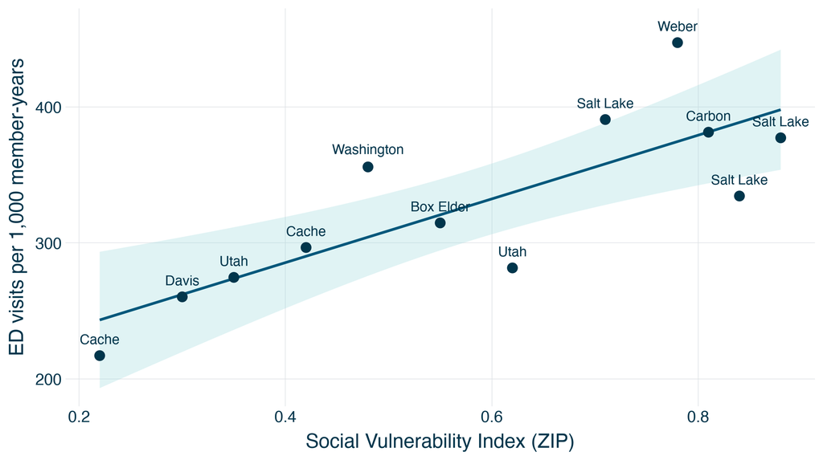

⚠️ **Ecological fallacy:** a ZIP’s SVI describes the *area*, not the person.

# Vendor Data

## Buying What You Can’t Observe

Vendors link consumer records to members and sell **person-level** social risk.

```python
v = members[["member_id"]].merge(
    vendor, on="member_id", how="left")
conf = v["match_confidence"]
print(f"Matched:          {conf.notna().mean():.0%}")
print(f"High-confidence:  {(conf >= .7).mean():.0%}")
```

```
Matched:          83%
High-confidence:  67%
```

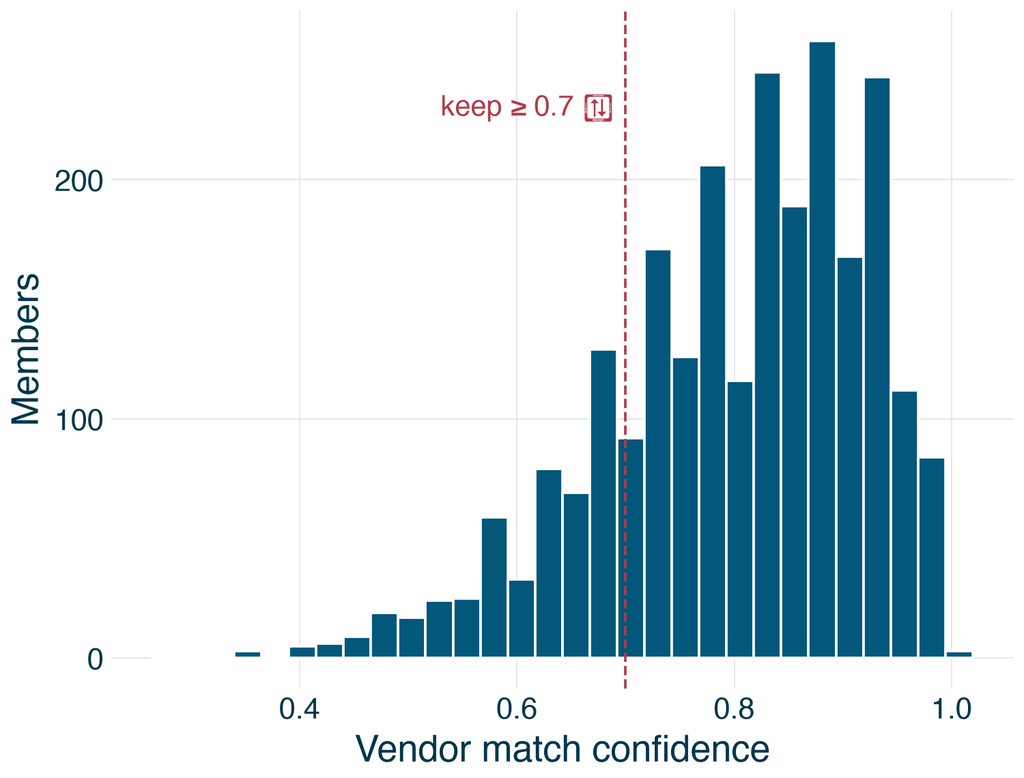

Ask every vendor: *how* did you match, *how* is this score built, and *who* is missing?

## Food Insecurity and the ED

```python
dat = (
    mem
    .merge(ed_n, on="member_id", how="left")
    .fillna({"ed_visits": 0})
    .merge(census, on="zip")
    .merge(vendor, on="member_id")
    .query("match_confidence >= 0.7")
)
dat["fi_q"] = pd.qcut(dat["food_insecurity_index"], 4, labels=["Q1 low", "Q2", "Q3", "Q4 high"])

q = (
    dat
    .groupby("fi_q", observed=True)
    [["ed_visits", "member_months"]]
    .sum()
)
q["per_1000"] = 12_000 * q["ed_visits"] / q["member_months"]
q["per_1000"].round(0)
```

```
fi_q
Q1 low     219.0
Q2         279.0
Q3         367.0
Q4 high    438.0
Name: per_1000, dtype: float64
```

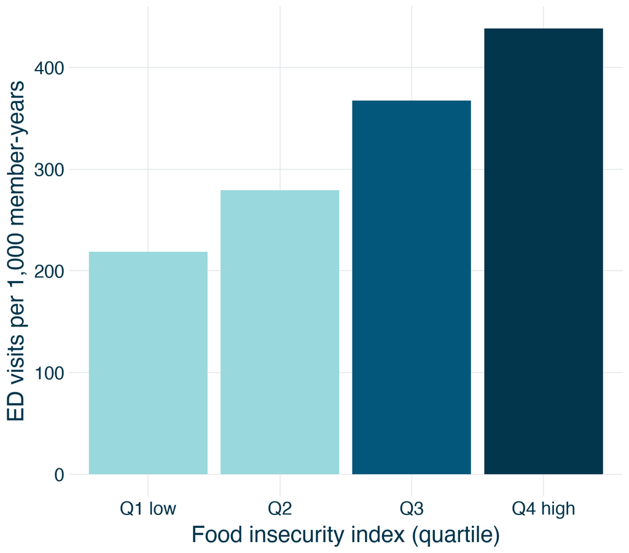

## Putting It All Together: A Poisson Model

ED visits are counts with unequal exposure, so use Poisson with an **offset** for member-months.

```python
dat["diabetes_dx"] = dat["member_id"].isin(dx).astype(int)
fit = smf.glm(
    "ed_visits ~ food_insecurity_index + svi + age + diabetes_dx + C(plan_type)",
    data = dat,
    family = sm.families.Poisson(),
    offset = np.log(dat["member_months"])
).fit()
```

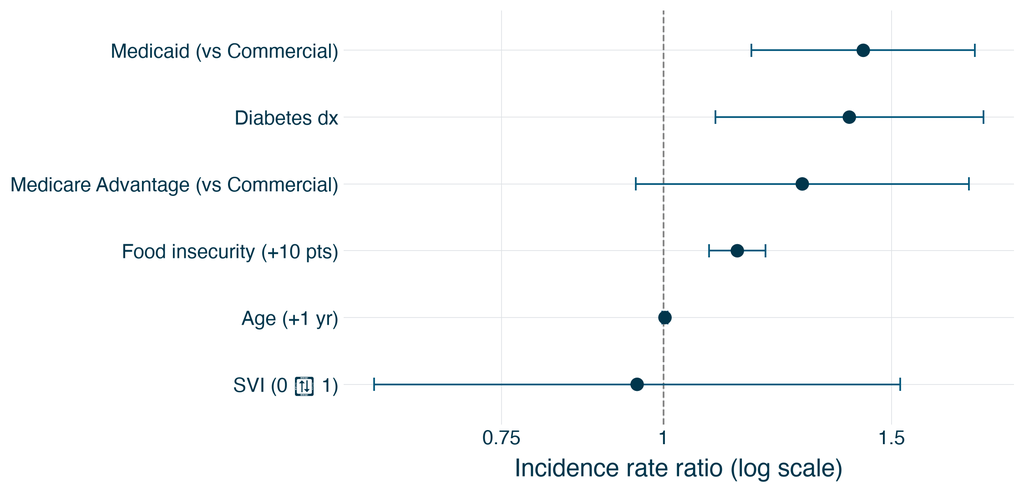

## Your Turn: Vendor + Model

**5 minutes**

1. Add `housing_instability` and `transportation_barrier` to the model. Do they matter after food insecurity?
2. Refit using **all** matched members (no confidence filter). Does the food-insecurity IRR change?

```python
fit2 = smf.glm("ed_visits ~ food_insecurity_index + housing_instability + transportation_barrier"
               " + svi + age + diabetes_dx + C(plan_type)", data=dat,
               family=sm.families.Poisson(), offset=np.log(dat["member_months"])).fit()
np.exp(fit2.params).round(2)
```

## Takeaways

1. **Claims** = cost & breadth · **EHR** = clinical depth · **Census** = context · **Vendor** = gaps filled (at a price)
2. Most of the work is **linking and cleaning**: reversals, crosswalks, implausible values, match rates
3. No single source finds everyone. **Combine them.**
4. The field is **growing**, and it rewards people who can *explain* results to clinicians and executives

**Keep playing:** all data is in `data/` and `data/make_data.py` regenerates it.

## Sources: Background & Careers

- Nundy S, Cooper LA, Mate KS. The Quintuple Aim for health care improvement: a new imperative to advance health equity. *JAMA*. 2022;327(6):521–522. [PMID 35061006](https://pubmed.ncbi.nlm.nih.gov/35061006/)
- Job postings (accessed Oct 16, 2026): [Intermountain Health, Data Analyst, Statistical Senior](https://jobs.alooba.com/us/job/intermountain-health-data-analyst-statistical-senior-836248/) · [Intermountain Health, Data Analyst-Technical-Staff](https://builtin.com/job/data-analyst-technical-staff/3484345) · [Optum, Senior Healthcare Analytics Consultant](https://careers.unitedhealthgroup.com/job/richardson/sr-healthcare-consultant-physician-medicare-and-analytics-remote/34088/101934064752) · [USM, HEDIS Data Analyst (SQL)](https://talents.vaia.com/companies/usm/hedis-data-analyst-sql-144611449/) · [Cohere Health, Senior Data Scientist](https://job-boards.greenhouse.io/coherehealth/jobs/7520590003) · [Dandelion Health, Research Consultant, Data Scientist](https://jobs.primary.vc/companies/dandelion-health-inc/jobs/94195881-research-consultant-data-scientist) · [GDIT, Sr. Healthcare Data Scientist (Medicare/Medicaid)](https://www.gdit.com/careers/job/079df090a/sr-healthcare-data-scientist-medicaremedicaid/)
- U.S. Bureau of Labor Statistics, *Occupational Outlook Handbook*: [Data Scientists](https://www.bls.gov/ooh/math/data-scientists.htm), [Medical & Health Services Managers](https://www.bls.gov/ooh/management/medical-and-health-services-managers.htm), [Health Information Technologists](https://www.bls.gov/ooh/healthcare/health-information-technologists-and-medical-registrars.htm), [Operations Research Analysts](https://www.bls.gov/ooh/math/operations-research-analysts.htm), [Mathematicians & Statisticians](https://www.bls.gov/ooh/math/mathematicians-and-statisticians.htm)

## Sources: Highmark Work

- Barrett TS, et al. Obesity treatment with bariatric surgery vs GLP-1 receptor agonists. *JAMA Surg*. 2025;160(11):1232–1239. [PMID 40960852](https://pubmed.ncbi.nlm.nih.gov/40960852/)
- Popkov AA, Barrett TS, et al. Depression symptom severity and total cost of care. *J Affect Disord*. 2025;368:41–47. [PMID 39271070](https://pubmed.ncbi.nlm.nih.gov/39271070/)
- Popkov AA, Barrett TS, et al. Claims-based depression identification and stratification. *J Behav Health Serv Res*. 2026;53(2):237–253. [PMID 40962946](https://pubmed.ncbi.nlm.nih.gov/40962946/)
- Jaffe E, …, Barrett TS. Payor-provider partnership in palliative care. *J Palliat Med*. 2025;28(8):1079–1086. [PMID 40323731](https://pubmed.ncbi.nlm.nih.gov/40323731/)
- Galper K, …, Barrett TS, et al. Social vulnerability and depression screening. *Am J Public Health*. 2025;115(9):1436–1444. [PMID 40609057](https://pubmed.ncbi.nlm.nih.gov/40609057/)
- Karlin BE, …, Barrett TS. Insomnia in a payor-provider system. *Sleep Adv*. 2024;5(1):zpae054. [PMID 39372542](https://pubmed.ncbi.nlm.nih.gov/39372542/)
- Breitzig MT, …, Barrett TS, et al. Measurement-based care and ED visits. *Adm Policy Ment Health*. 2026;53(4):462–474. [PMID 42096017](https://pubmed.ncbi.nlm.nih.gov/42096017/)